# Lab 1: Gene expression microarrays and differential expression

March 25, 2014

## Goals of the lab

Today we will

- get familiar Affymetrix data
- produce diagnostic plots with basis R commands (Boxplots, densities, MA plots)
- normalize expression data (Quantile normalization, RMA)
- perform a differential analysis with limma (Linear model, Empirical Bayes)
- correct for multiple comparison (Bonferroni, Benjamini & Hochberg )

## Loading packages:

First let's load the **affy** and **affydata** packages from Bioconductor:

```r
library(affy)
library(affydata)
```

To load into R a dataset containing 4 Affymetrix samples:

```r
data(Dilution)
pData(Dilution) #Phenotype information
```

```
##     liver sn19 scanner
## 20A    20    0       1
## 20B    20    0       2
## 10A    10    0       1
## 10B    10    0       2
```

## Raw intensities

Remember that most of the Affymetrix arrays contain two intensities for each probe: one for perfect match **(PM)** and one for mismatch **(MM)**. We will only with the PM intensities

```r
# To obtain the matrix of PM intensities:
raw <- pm(Dilution)
head(raw, n=3)
```

```
##           20A   20B 10A   10B
## 175218  221.3 146.3 192 116.0
## 356689  685.0 479.0 493 328.3
## 227696 1126.3 724.3 849 498.3
```

## Log-Intensities densities

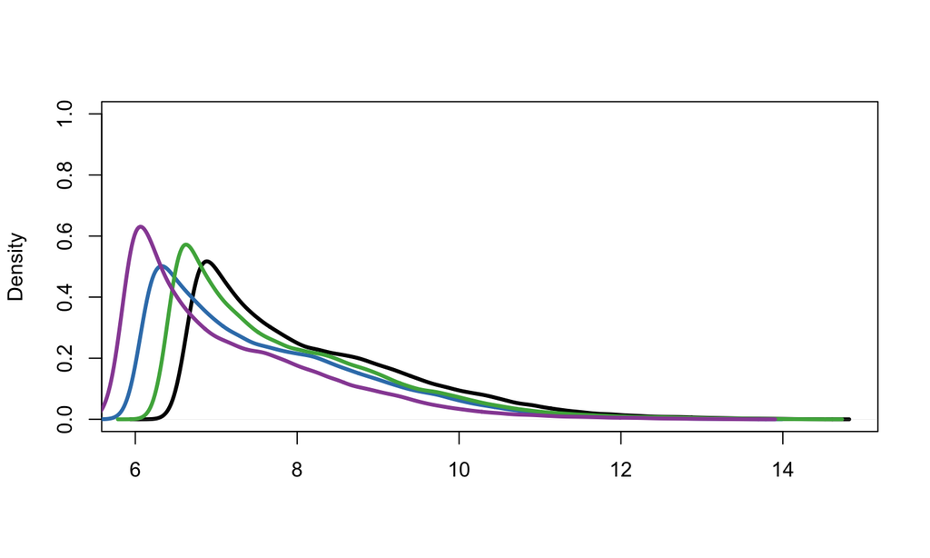

```r
log.raw <- log2(raw)
plot(density(log.raw[,1]), ylim=c(0,1), xlab="",main="", lwd=3)
for (i in 2:4){lines(density(log.raw[,i]),col=i, lwd=3)}
```

## Log-Intensities Sample 1 vs Sample 2

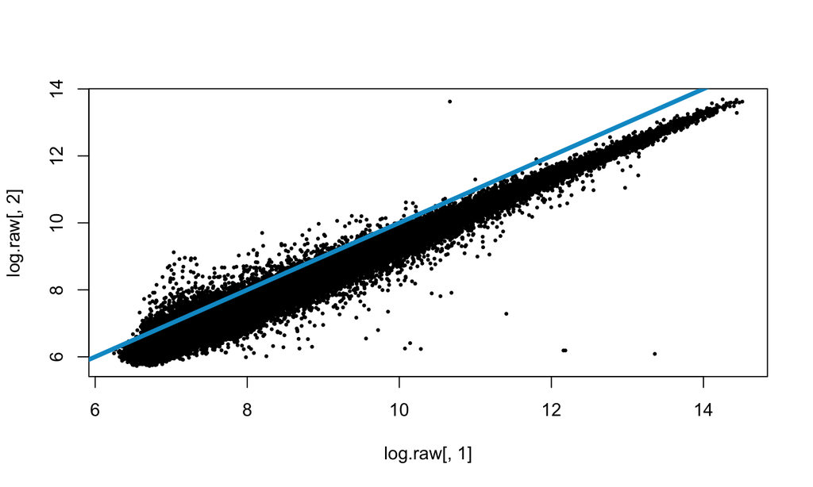

```r
plot(log.raw[,1], log.raw[,2], pch=20, cex=0.5)
abline(a=0,b=1,col="deepskyblue3", lwd=4)
```

## MA plot (Bland–Altman plot)

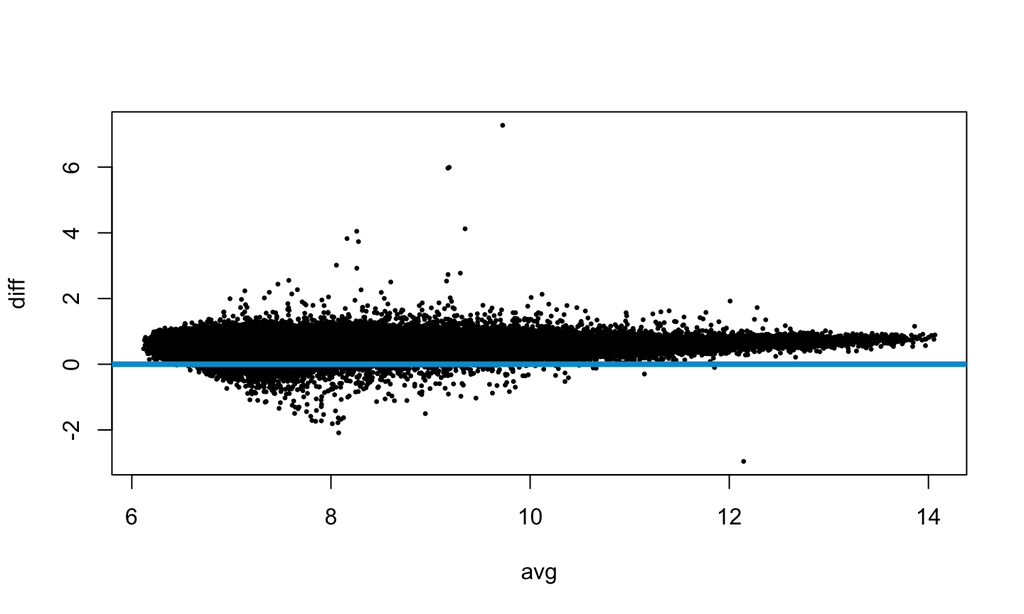

```r
avg  <- (log.raw[,1] + log.raw[,2])/2
diff <-  log.raw[,1] - log.raw[,2]
plot(avg, diff, pch=20, cex=0.5)
abline(h=0,col="deepskyblue3", lwd=4)
```

## Lowess curve

http://simplystatistics.org/2014/02/13/loess-explained-in-a-gif/loess/

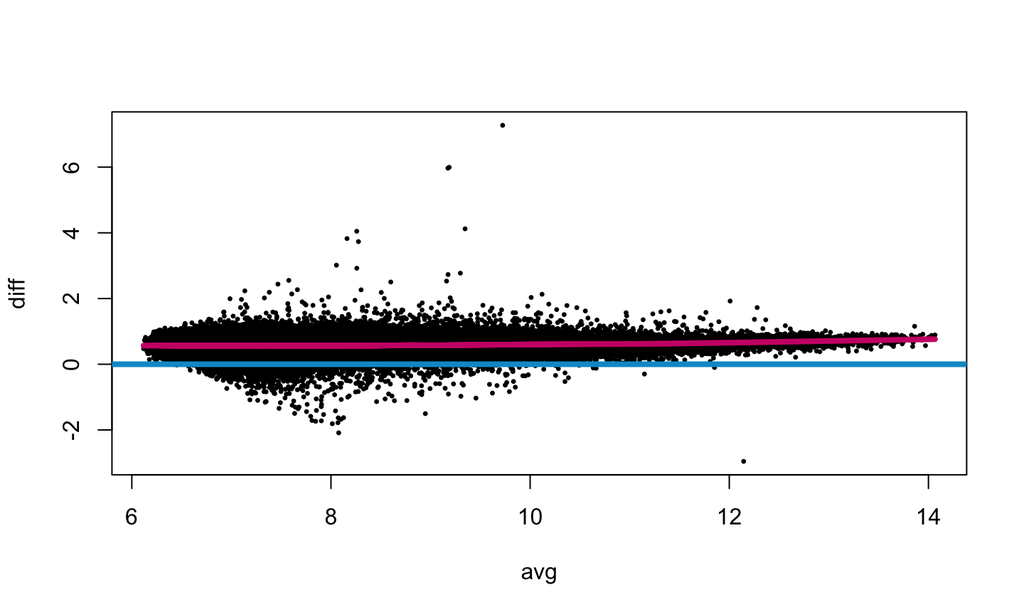

```r
lowess.curve <- lowess(x = avg, y = diff, f = 0.05)
#f controls the smoothing span
lines(lowess.curve, col = "deeppink3", lwd = 4)
```

## Quantile normalization

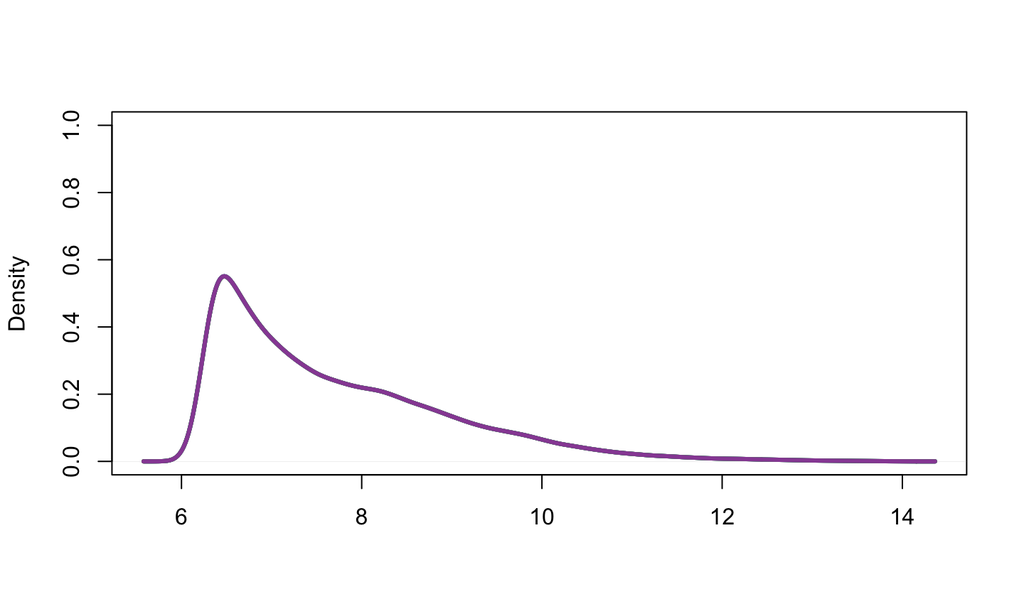

```r
qn <- preprocessCore::normalize.quantiles(log.raw)

plot(density(qn[,1]), ylim=c(0,1), xlab="",main="", lwd=3)
for (i in 2:4){lines(density(qn[,i]),col=i, lwd=3)}
```

## MA plot after quantile normalization

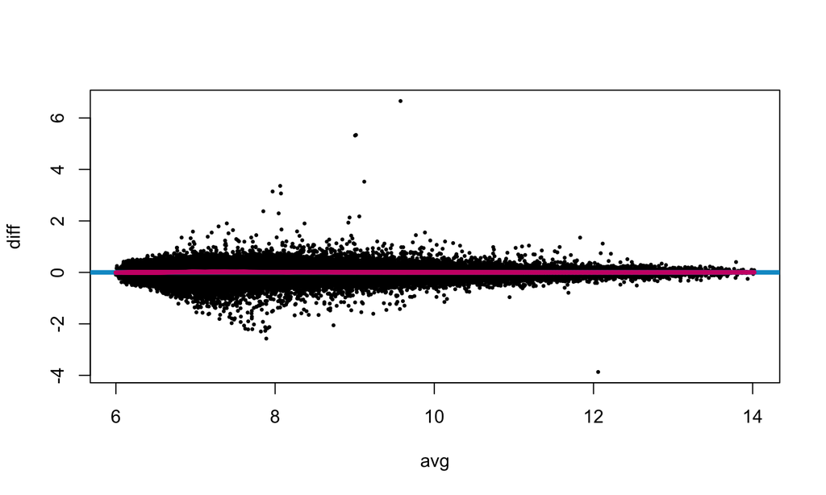

## Exercise 1

- Read about loess/lowess normalization.
- Normalize samples 1 and 2 using the lowess curve that we computed
- How does the MA plot look like after normalization? Does it look better than quantile normalization?

## Scatterplot smoothing

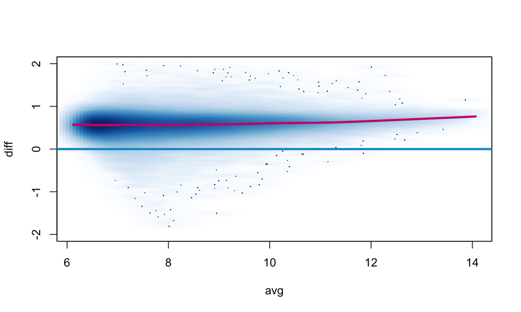

```r
smoothScatter(avg, diff, ylim = c(-2,2))
lines(lowess.curve, col = "deeppink3", lwd = 3)
abline(h=0, col = "deepskyblue3", lwd=3)
```

## Probe sets

A set of probes targeting the same gene is called a **probeset**. First, let's get the probe name for each row of the PM (or MM) matrix:

```r
probe.names <- probeNames(Dilution)
head(probe.names, n=20)
```

```
##  [1] "100_g_at" "100_g_at" "100_g_at" "100_g_at" "100_g_at" "100_g_at"
##  [7] "100_g_at" "100_g_at" "100_g_at" "100_g_at" "100_g_at" "100_g_at"
## [13] "100_g_at" "100_g_at" "100_g_at" "100_g_at" "1000_at"  "1000_at"
## [19] "1000_at"  "1000_at"
```

The first 16 rows of the PM matrix are probes that belong to the same probeset.

## Gene ids

To obtain the list of probeset ids:

```r
geneNames(Dilution)
# which is equivalent to
unique(probe.names)
```

To get the PM intensities for a given probeset (here the 20th):

```r
x <- pm(Dilution, geneNames(Dilution)[20])
head(x, n=3)
```

```
##            20A   20B 10A  10B
## 1017_at1 149.0  92.0 115 83.3
## 1017_at2 110.3  65.0 103 57.0
## 1017_at3 176.3 116.8 165 90.8
```

## Exercise 2

Can you obtain the median polished intensities for the first probeset ? (look at the class notes to see an example of the median polish algorithm)

## RMA

RMA performs background correction, quantile normalization and applies the median polish algorithm to summarize the probeset intensities. Only need one command:

```r
eset <- rma(Dilution)
```

```
## Background correcting
## Normalizing
## Calculating Expression
```

```r
nrow(eset)
```

```
## Features
##    12625
```

## RMA

The **rma** command returns an ExpressionSet.

```r
eset
```

```
## ExpressionSet (storageMode: lockedEnvironment)
## assayData: 12625 features, 4 samples
##   element names: exprs
## protocolData: none
## phenoData
##   sampleNames: 20A 20B 10A 10B
##   varLabels: liver sn19 scanner
##   varMetadata: labelDescription
## featureData: none
## experimentData: use 'experimentData(object)'
## Annotation: hgu95av2
```

## RMA

Use **exprs** to obtain the summarized expression measures:

```r
e <- exprs(eset)
head(e)
```

```
##             20A   20B   10A   10B
## 100_g_at  8.040 7.892 8.022 7.911
## 1000_at   7.791 7.661 7.717 7.623
## 1001_at   5.176 5.067 5.083 5.092
## 1002_f_at 5.917 5.755 5.817 5.742
## 1003_s_at 6.335 6.010 6.198 6.134
## 1004_at   6.391 6.148 6.358 6.261
```

```r
dim(e)
```

```
## [1] 12625     4
```

## Affy diagnostic plots

The **affy** package contains plot commands to draw boxplots, densities and MA plots

```r
boxplot(Dilution)
hist(Dilution)
MAplot(Dilution, pairs=TRUE)
MAplot(Dilution, pairs=TRUE, plot.method="smoothScatter")
```

We are now ready to perform a differential expression analysis.

## Differential analysis with limma

**Goal:** Find genes that have significantly significant different abundances between two (or more) groups. Our dataset only has 4 samples, with no interesting biological treatment group, but we will use it for demonstration purpose. We will use the package **limma**:

```r
library(limma)
```

First let's define a comparison group:

```r
pd <- pData(Dilution)
groups <- as.factor(pd$liver)
```

## DE Analysis

We need to construct a design matrix:

```r
design.matrix <- model.matrix(~groups)
colnames(design.matrix) <- c("Intercept","Treatment")
design.matrix
```

```
##   Intercept Treatment
## 1         1         1
## 2         1         1
## 3         1         0
## 4         1         0
## attr(,"assign")
## [1] 0 1
## attr(,"contrasts")
## attr(,"contrasts")$groups
## [1] "contr.treatment"
```

## Linear model

We fit a linear model using the **lmFit** function in **limma**. All we need is an expression matrix containing the summarized intensities and a design matrix.

```r
fit <- lmFit(e, design.matrix)
```

**fit** is an object containing the results of the fits. For instance, one can retrieve the coefficients of the linear model by

```r
head(fit$coefficients)
```

```
##           Intercept  Treatment
## 100_g_at      7.967 -0.0007583
## 1000_at       7.670  0.0562669
## 1001_at       5.087  0.0340578
## 1002_f_at     5.779  0.0562073
## 1003_s_at     6.166  0.0066700
## 1004_at       6.309 -0.0400013
```

## Linear model

Note that the **fit** object does not contain any statistical test nor p-value. For each gene, we fitted the model \[y_{i} = \beta_0 + \beta_1 x_i\] where \(y_i\) is the expression value for sample \(i\), \(\beta_0\) is an intercept, \(x_i\) is a dummy variable equal to 0 for the first group and 1 for the second group, and \(\beta_1\) is the coefficient associated with the change in expression between the two groups. Our goal is to test whether or not \(\beta_1 = 0\). The classical t-statistic is \[ t = \frac{\hat{\beta_1}}{\frac{s}{\sqrt{n}}}\]

## Classical t-statistic

How can we obtain the t-statistics from the object returned by **lmFit()**?

```r
beta <- fit$coefficient[,2]
s <- fit$stdev.unscaled[,2]
n <- 4
t <- (beta*sqrt(n))/s
```

Can you extract the p-value for each gene?

## Empirical Bayes

Computing classical t-statistics for experiments with a small number of arrays is unstable. The Empirical Bayes method implemented in **limma** borrows information across genes to make the analysis more stable.The function **eBayes** computes moderated t-statistics by estimating the standard errors using empirical Bayes moderation:

```r
fit2 <- eBayes(fit)
```

## Volcano plot

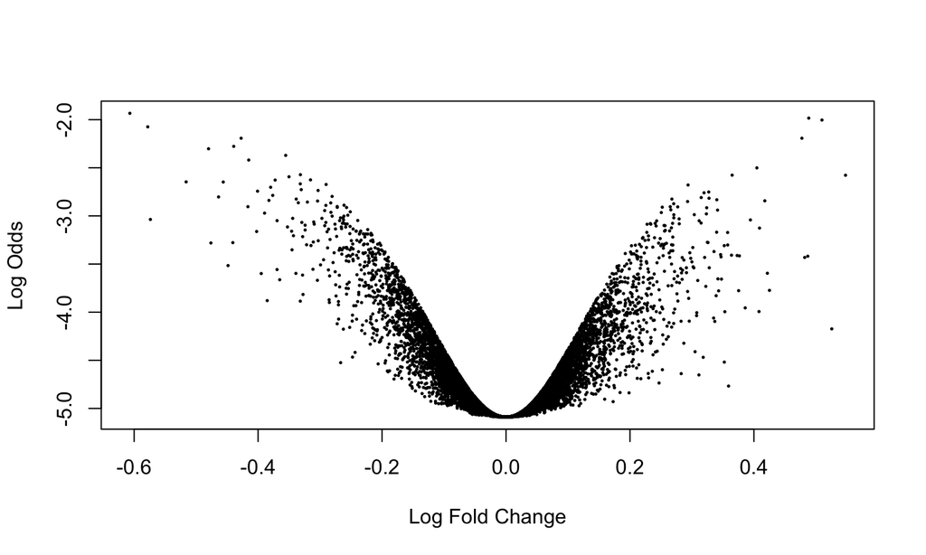

```r
volcanoplot(fit2, coef=2)
```

## Exercise 3

- Repeat the differential expression analysis, but this time testing for the difference between samples from scanner 1 and samples from scanner 2 (see phenotype information)
- Produce a p-values (computed with **eBayes**) histogram
- Repeat the analysis but this time with data that haven't been background corrected and that are not normalized. Use the median polish algorithm for the probeset summarization. Use the function **expresso()** in the **affy** package to produce such an expression matrix.
- What can you tell about the p-values produced with the RMA-corrected dataset? What can you tell about the p-values produced with the uncorrected data?

## To do:

- Background subtraction